# ⚾ MLB Pitch-by-Pitch Velocity Analysis & Scouting Report

## 🧭 Project Overview

This project analyzes MLB pitch-by-pitch data across multiple seasons to evaluate **pitcher performance** using **velocity-based grading**. It produces detailed insights for pitchers, teams, stadiums, and pitch types — helping answer: *Who throws the best pitches, where, and for whom?*

## 📊 Core Components

### 1. **Pitcher Velocity Grading**

- Velocity difference from league average per pitch type
- Graded on a 5-point scale: A (elite) to F (below average)
- Covers **Starters** and **Relievers** separately

### 2. **Pitch Sequences**

- Extracted full pitch sequences per batter
- Saved by season for trend analysis

### 3. **Team-Level Analysis**

- Total Grade A pitch count per team (Starters + Relievers)
- Seasonal trend plots: top improving vs declining staffs
- Combined velocity-based score = bullpen + rotation

### 4. **Stadium Analysis**

- Velocity profile of each stadium
- Top performers by ballpark
- Normalized comparisons to identify bullpen/starter strengths at home

## File Outputs

- `/data/processed/`
  - `pitcher_velocity_grades.csv`
  - `top_pitchers_by_pitch_type.csv`
  - `team_staff_strength.csv`
  - `pitcher_rankings_by_team.csv`
  - `stadium_pitching_grades.csv`
- `/reports/figures/`
  - `top_10_improved_teams.png`
  - `top_10_declining_teams.png`
  - `stadium_grade_A_starters_2022.png`
  - `BOS_2025_pitcher_heatmap_with_legend.png`

## 🧠 Future Work

- 🎓 Add spin rate, whiff %, and expected outcomes to grade performance
- 🔍 Overlay letter grades on all heatmaps
- 🔁 Automate heatmap creation across all 30 MLB teams
- 🧬 Cluster pitchers with similar pitch profiles using ML

## 🧑‍💻 Tools Used

- Python (Pandas, Seaborn, Matplotlib)
- pybaseball for data acquisition
- Statcast data from 2022–2025

## ✅ Outcome

This pipeline provides **elite scouting visibility** into every MLB pitch and pitcher. Whether for player evaluation, team construction, or visual analysis — this project is a flexible, extensible foundation for **data-driven baseball intelligence**.

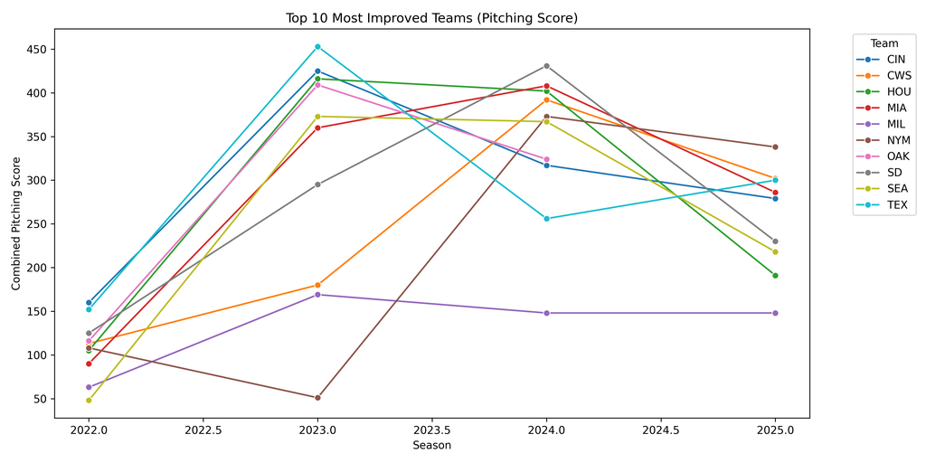

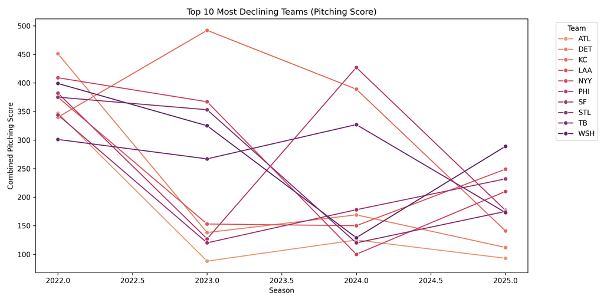

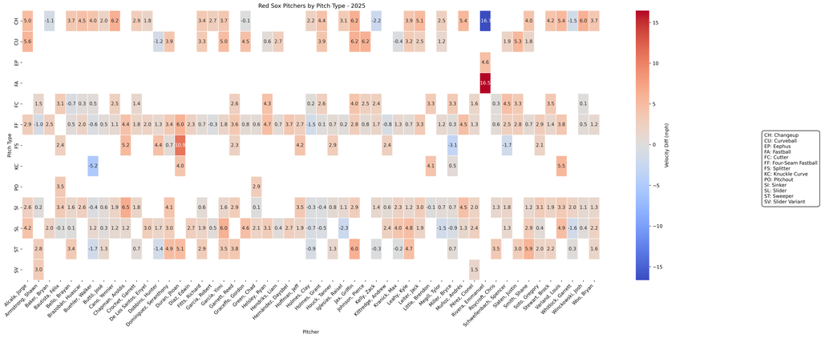

```python
from IPython.display import Image, display

# Display top team trend plots
display(Image(filename="F:/Portfolio/baseball-pitch-analysis/reports/figures/top_10_improved_teams.png"))
display(Image(filename="F:/Portfolio/baseball-pitch-analysis/reports/figures/top_10_declining_teams.png"))

# Display heatmap for Red Sox
display(Image(filename="F:/Portfolio/baseball-pitch-analysis/reports/figures/BOS_2025_pitcher_heatmap_with_legend.png"))
```

```python
import pandas as pd

summary = pd.read_csv("F:/Portfolio/baseball-pitch-analysis/data/processed/team_staff_strength.csv")
summary.head()
```

|  | season | team | team_total_grade_a |
| --- | --- | --- | --- |
| 0 | 2022 | NYY | 6983 |
| 1 | 2022 | MIA | 6692 |
| 2 | 2022 | MIL | 6154 |
| 3 | 2022 | ATL | 6101 |
| 4 | 2022 | CWS | 5938 |